# Exploratory Data Analysis Course Project

Tanmoy Rath

3 April 2019

## Background

Fine particulate matter (PM2.5) is an ambient air pollutant for which there is strong evidence that it is harmful to human health. In the United States, the Environmental Protection Agency (EPA) is tasked with setting national ambient air quality standards for fine PM and for tracking the emissions of this pollutant into the atmosphere. Approximatly every 3 years, the EPA releases its database on emissions of PM2.5. This database is known as the National Emissions Inventory (NEI). You can read more information about the NEI at the [EPA National Emissions Inventory web site](https://www3.epa.gov/ttn/chief/eiinformation.html).

For each year and for each type of PM source, the NEI records how many tons of PM2.5 were emitted from that source over the course of the entire year. The data that was used for this assignment were for 1999, 2002, 2005, and 2008.

## Data

The data for this assignment were available in two files

- summarySCC_PM25.rds
- Source_Classification_Code.rds

PM2.5 Emissions Data (**summarySCC_PM25.rds**): This file contains a data frame with all of the PM2.5 emissions data for 1999, 2002, 2005, and 2008. For each year, the table contains number of tons of PM2.5 emitted from a specific type of source for the entire year. Here are the first few rows.

```
##     fips      SCC Pollutant Emissions  type year
## 4  09001 10100401  PM25-PRI    15.714 POINT 1999
## 8  09001 10100404  PM25-PRI   234.178 POINT 1999
## 12 09001 10100501  PM25-PRI     0.128 POINT 1999
## 16 09001 10200401  PM25-PRI     2.036 POINT 1999
## 20 09001 10200504  PM25-PRI     0.388 POINT 1999
## 24 09001 10200602  PM25-PRI     1.490 POINT 1999
```

- **fips**: A five-digit number (represented as a string) indicating the U.S. county
- **SCC**: The name of the source as indicated by a digit string (see source code classification table)
- **Pollutant**: A string indicating the pollutant
- **Emissions**: Amount of PM2.5 emitted, in tons
- **type**: The type of source (point, non-point, on-road, or non-road)
- **year**: The year of emissions recorded

Source Classification Code Table (**Source_Classification_Code.rds**): This table provides a mapping from the SCC digit strings in the Emissions table to the actual name of the PM2.5 source. The sources are categorized in a few different ways from more general to more specific and you may choose to explore whatever categories you think are most useful. For example, source “10100101” is known as “Ext Comb /Electric Gen /Anthracite Coal /Pulverized Coal”.

## Course Project Questions

Following questions were addressed in the course assignment

- Have total emissions from PM2.5 decreased in the United States from 1999 to 2008? Using the **base** plotting system, make a plot showing the total PM2.5 emission from all sources for each of the years 1999, 2002, 2005, and 2008.
- Have total emissions from PM2.5 decreased in the **Baltimore City**, Maryland (**fips==“24510”**) from 1999 to 2008? Use the **base** plotting system to make a plot answering this question.
- Of the four types of sources indicated by the **type** (point, nonpoint, onroad, nonroad) variable, which of these four sources have seen decreases in emissions from 1999–2008 for **Baltimore City**? Which have seen increases in emissions from 1999–2008? Use the **ggplot2** plotting system to make a plot answer this question.
- Across the United States, how have emissions from coal combustion-related sources changed from 1999–2008?
- How have emissions from motor vehicle sources changed from 1999–2008 in **Baltimore City**?
- Compare emissions from motor vehicle sources in Baltimore City with emissions from motor vehicle sources in **Los Angeles County**, California (**fips==“06037”**). Which city has seen greater changes over time in motor vehicle emissions?

## Data Exploration & Cleaning

```r
# Reading the data
NEI <- readRDS("summarySCC_PM25.rds")
SCC <- readRDS("Source_Classification_Code.rds")

# The columns needed for the assignment are NEI$year, NEI$Emissions, NEI$fips, SCC$EI.Sector, SCC$SCC
# Checking them for NA values...
c(
sum(is.na(  NEI$year  )),
sum(is.na(  NEI$Emissions  )),
sum(is.na(  NEI$fips  )),
      sum(  NEI$fips==" "  ),
      sum(  NEI$fips==""  ),
sum(is.na(  SCC$EI.Sector  )),
      sum(  SCC$EI.Sector==" "  ),
      sum(  SCC$EI.Sector==""  ),
sum(is.na(  SCC$SCC  )),
      sum(  SCC$SCC==" "  ),
      sum(  SCC$SCC==""  )
)
```

```
##  [1] 0 0 0 0 0 0 0 0 0 0 0
```

All the above sums, were found to be zero, hence there aren’t any NA values in those columns.

#### Question 1

- Have total emissions from PM2.5 decreased in the United States from 1999 to 2008? Using the **base** plotting system, make a plot showing the total PM2.5 emission from all sources for each of the years 1999, 2002, 2005, and 2008.

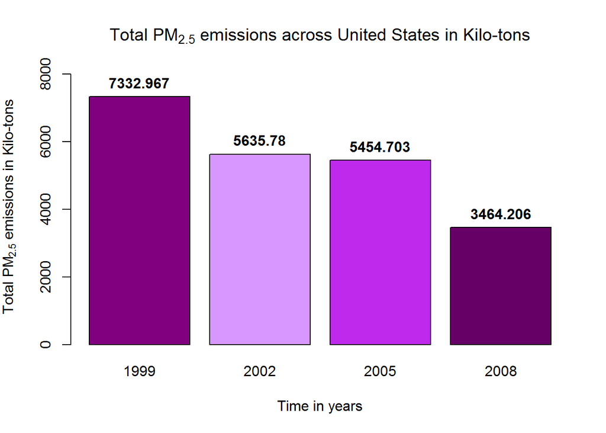

```r
total_emissions <- dplyr::summarise(  dplyr::group_by(NEI, year), Emissions=sum(Emissions)  )

# PLOT
par(bg="#FFFFFF")
plot <- barplot(height = total_emissions$Emissions/1000, # dividing by 1000 converts y-axis to kilo-tons
                xlab="Time in years", ylab=expression('Total PM'[2.5]*' emissions in Kilo-tons'),
                ylim=c(0,8100),
                names.arg = total_emissions$year,
                main=expression('Total PM'[2.5]*' emissions across United States in Kilo-tons'),col=c("#800080","#D896FF","#BE29EC","#660066"))

## Adding values above the bars
text(x = plot,
     y = round(total_emissions$Emissions/1000,6),
     label = round(total_emissions$Emissions/1000,3),
     pos = 3, cex = 1, col = "black", font=2)
```

- **Answer**: Yes, the total emissions from all the sources of PM2.5, in the United States, have decreased from 1999 to 2008.

#### Question 2

- Have total emissions from PM2.5 decreased in the **Baltimore City**, Maryland (**fips==“24510”**) from 1999 to 2008? Use the **base** plotting system to make a plot answering this question.

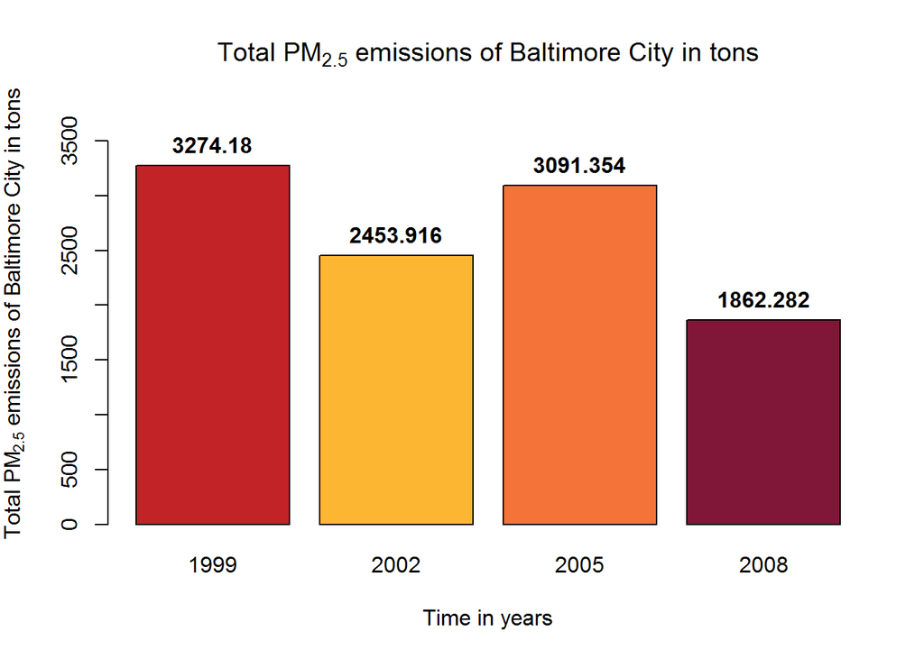

```r
baltimore <- NEI[NEI$fips=="24510",]
total_emissions <- dplyr::summarise(  dplyr::group_by(baltimore, year), Emissions=sum(Emissions)  )

# PLOT
par(bg="#FFFFFF")
plot <- barplot(height = total_emissions$Emissions,
                xlab="Time in years", ylab=expression('Total PM'[2.5]*' emissions of Baltimore City in tons'),
                ylim=c(0,3800),
                names.arg = total_emissions$year,
                main=expression('Total PM'[2.5]*' emissions of Baltimore City in tons'),col=c("#C22326","#FDB632","#F37338","#801638"))

## Adding values above the bars
text(x = plot,
     y = round(total_emissions$Emissions,6),
     label = round(total_emissions$Emissions,3),
     pos = 3, cex = 1, col = "black", font=2)
```

- **Answer**: Yes, the total emissions from PM2.5 in Baltimore City, Maryland, have decreased from 1999 to 2008.

#### Question 3

- Of the four types of sources indicated by the **type** (point, nonpoint, onroad, nonroad) variable, which of these four sources have seen decreases in emissions from 1999–2008 for **Baltimore City**? Which have seen increases in emissions from 1999–2008? Use the **ggplot2** plotting system to make a plot answer this question.

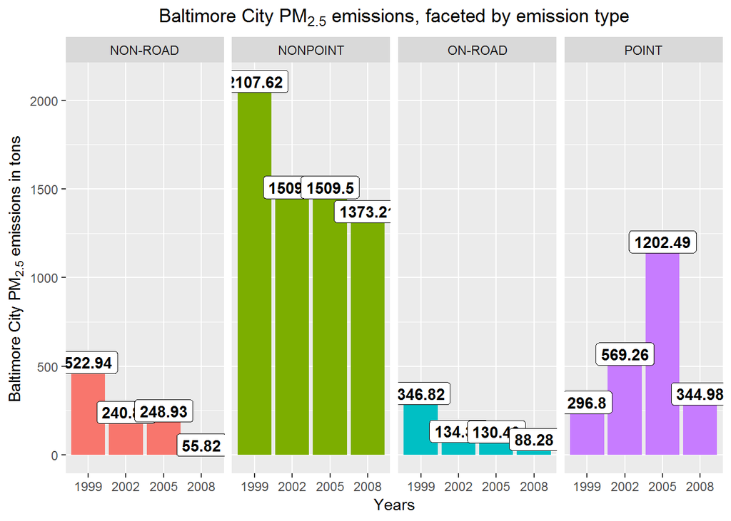

```r
baltimore <- NEI[NEI$fips=="24510",]
total_emissions <- dplyr::summarise(  dplyr::group_by(baltimore, type, year), Emissions=sum(Emissions)  )

# PLOT
library(ggplot2)
ggplot(data=total_emissions, mapping = aes(x=factor(year),y=Emissions,fill=type)) +
    geom_bar(stat="identity") +
    geom_label(aes(label=round(Emissions,2)), colour = "black", fontface = "bold", fill="white")+
    facet_grid(.~type)+
    xlab("Years")+
    ylab(expression('Baltimore City PM'[2.5]*' emissions in tons'))+
    ggtitle(label=expression('Baltimore City PM'[2.5]*' emissions, faceted by emission type'))+
    theme(plot.title = element_text(hjust = 0.5),legend.position="none")
```

- **Answer**: **POINT** source has decreased only in 2008, it was increasing previously. Hence, excluding **POINT** source, emissions from all other sources of PM2.5 in Baltimore City, Maryland, can be said to have decreased from 1999 to 2008.

#### Question 4

- Across the United States, how have emissions from coal combustion-related sources changed from 1999–2008?

**SCC$EI.Sector** lists the sources of combustion

```r
unique(SCC$EI.Sector)
```

```
##  [1] Fuel Comb - Electric Generation - Coal
##  [2] Fuel Comb - Electric Generation - Oil
##  [3] Fuel Comb - Electric Generation - Natural Gas
##  [4] Fuel Comb - Electric Generation - Other
##  [5] Fuel Comb - Electric Generation - Biomass
##  [6] Fuel Comb - Industrial Boilers, ICEs - Coal
##  [7] Fuel Comb - Industrial Boilers, ICEs - Oil
##  [8] Fuel Comb - Industrial Boilers, ICEs - Natural Gas
##  [9] Fuel Comb - Industrial Boilers, ICEs - Other
## [10] Fuel Comb - Industrial Boilers, ICEs - Biomass
## [11] Fuel Comb - Comm/Institutional - Coal
## [12] Fuel Comb - Comm/Institutional - Oil
## [13] Fuel Comb - Comm/Institutional - Natural Gas
## [14] Fuel Comb - Comm/Institutional - Other
## [15] Fuel Comb - Comm/Institutional - Biomass
```

[output cut: 45 more lines]

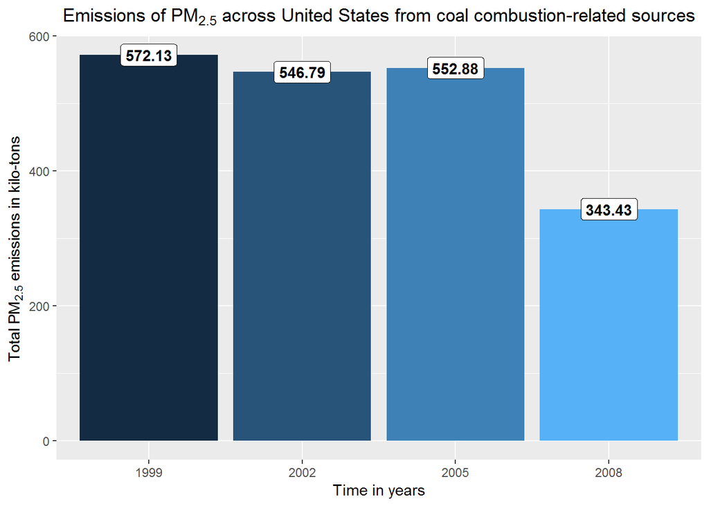

```r
# From the list of unique, the 3 sources given below are the coal combustion sources
# "Fuel Comb - Electric Generation - Coal"
# "Fuel Comb - Comm/Institutional - Coal"
# "Fuel Comb - Industrial Boilers, ICEs - Coal"

sources <- SCC$EI.Sector %in% c(
        "Fuel Comb - Electric Generation - Coal",
        "Fuel Comb - Comm/Institutional - Coal",
        "Fuel Comb - Industrial Boilers, ICEs - Coal")

coal <- NEI$SCC %in% SCC[sources,]$SCC
nei_coal <- NEI[coal,]

total_emissions <- dplyr::summarise(  dplyr::group_by(nei_coal, year), Emissions=sum(Emissions)/1000  )

# PLOT
ggplot(data=total_emissions, mapping = aes(x=factor(year),y=Emissions,fill=year))+
    geom_bar(stat="identity")+
    geom_label(aes(label=round(Emissions,2)), colour = "black", fontface = "bold", fill="white")+
    xlab("Time in years")+
    ylab(expression('Total PM'[2.5]*' emissions in kilo-tons'))+
    ggtitle(label=expression('Emissions of PM'[2.5]*' across United States from coal combustion-related sources'))+
    theme(plot.title = element_text(hjust = 0.5),legend.position="none")
```

- **Answer**: Emissions from coal combustion-related sources, across the United States, have reduced from 1999–2008.

#### Question 5

- How have emissions from motor vehicle sources changed from 1999–2008 in **Baltimore City**?

**SCC$EI.Sector** lists the sources of combustion

```r
unique(SCC$EI.Sector)
```

```
##  [1] Fuel Comb - Electric Generation - Coal
##  [2] Fuel Comb - Electric Generation - Oil
##  [3] Fuel Comb - Electric Generation - Natural Gas
##  [4] Fuel Comb - Electric Generation - Other
##  [5] Fuel Comb - Electric Generation - Biomass
##  [6] Fuel Comb - Industrial Boilers, ICEs - Coal
##  [7] Fuel Comb - Industrial Boilers, ICEs - Oil
##  [8] Fuel Comb - Industrial Boilers, ICEs - Natural Gas
##  [9] Fuel Comb - Industrial Boilers, ICEs - Other
## [10] Fuel Comb - Industrial Boilers, ICEs - Biomass
## [11] Fuel Comb - Comm/Institutional - Coal
## [12] Fuel Comb - Comm/Institutional - Oil
## [13] Fuel Comb - Comm/Institutional - Natural Gas
## [14] Fuel Comb - Comm/Institutional - Other
## [15] Fuel Comb - Comm/Institutional - Biomass
```

[output cut: 45 more lines]

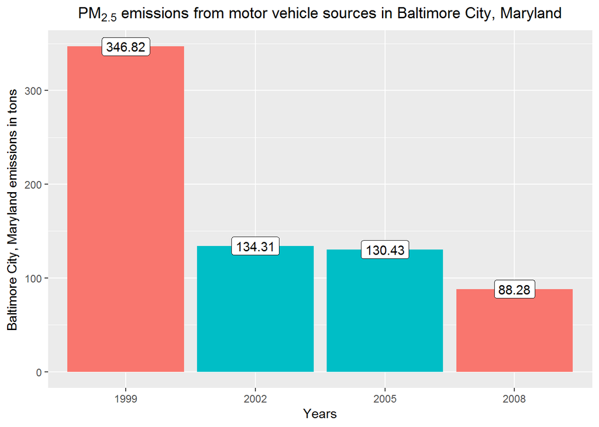

```r
# From the list of unique, these 4 sources given below are sources of emissions from motor vehicles
sources <- c(
        "Mobile - On-Road Gasoline Light Duty Vehicles",
        "Mobile - On-Road Gasoline Heavy Duty Vehicles",
        "Mobile - On-Road Diesel Light Duty Vehicles",
        "Mobile - On-Road Diesel Heavy Duty Vehicles")

scc2 <- SCC[ SCC$EI.Sector %in% sources, ]
temp <- NEI[ NEI$SCC %in% scc2$SCC, ]
baltimore <- temp[ temp$fips %in% "24510", ]

total_emissions <- dplyr::summarise( dplyr::group_by(baltimore, year), Emissions=sum(Emissions))

# PLOT
ggplot(data=total_emissions, mapping = aes(x=factor(year), y=Emissions))+
        geom_bar(stat="identity",fill=c("#F9766E","#00BEC6","#00BEC6","#F9766E"))+
        geom_label(mapping = aes(x=factor(year),y=Emissions,label=round(Emissions,2)))+
        xlab("Years")+
        ylab(expression('Baltimore City, Maryland emissions in tons'))+
        ggtitle(label=expression('PM'[2.5]*' emissions from motor vehicle sources in Baltimore City, Maryland'))+
        theme(plot.title = element_text(hjust = 0.5))
```

- **Answer**: Yes, the emissions from motor vehicles sources, in Baltimore City, have reduced from 1999–2008.

#### Question 6

- Compare emissions from motor vehicle sources in Baltimore City with emissions from motor vehicle sources in **Los Angeles County**, California (**fips==“06037”**). Which city has seen greater changes over time in motor vehicle emissions?

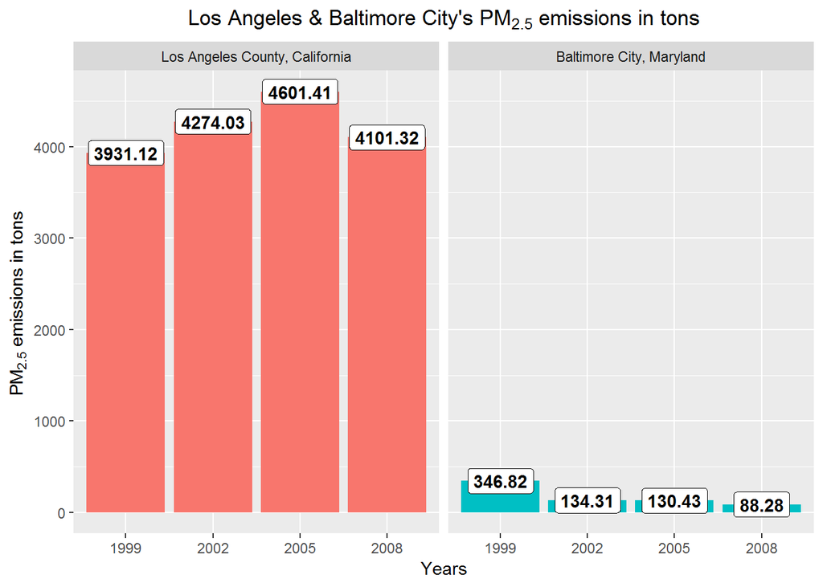

```r
scc2 <- SCC[ SCC$EI.Sector %in% sources, ]
temp <- NEI[ NEI$SCC %in% scc2$SCC, ]
bal_los <- temp[ temp$fips %in% c("24510","06037"), ]
bal_los$fips <- as.factor(bal_los$fips)
levels(bal_los$fips) <- c("Los Angeles County, California","Baltimore City, Maryland")

total_emissions <- dplyr::summarise( dplyr::group_by(bal_los, fips, year), Emissions=sum(Emissions) )

# PLOT
ggplot(data=total_emissions, mapping = aes(x=factor(year),y=Emissions,fill=fips))+
        geom_bar(stat="identity")+
        geom_label(aes(label=round(Emissions,2)), colour = "black", fontface = "bold", fill="white")+
        facet_grid(.~fips)+
        xlab("Years")+
        ylab(expression('PM'[2.5]*' emissions in tons'))+
        ggtitle(label=expression('Los Angeles & Baltimore City\'s PM'[2.5]*' emissions in tons'))+
        theme(plot.title = element_text(hjust = 0.5),legend.position="none")
```

- **Answer**: Baltimore City, Maryland, has seen greater amount of changes than Los Angeles County, California, by proportion of pollution. In fact, Baltimore City has much much cleaner air than Los Angeles County.

## Conclusion

This brings us to the end of the course assignment which was answered sufficiently by the plotting systems of R.